# Relational Data Homework

This homework is going to play around with relational joins. We will use some flight data from 2013 in New York City[^1].

```r
library( nycflights13 )
```

This library has five different data frames. Here is an overview of the raw data.

## The Data

A table of airline carrier abbreviations (N = 16 different carriers).

```r
head( airlines )
```

| carrier | name |
| --- | --- |
| 9E | Endeavor Air Inc. |
| AA | American Airlines Inc. |
| AS | Alaska Airlines Inc. |
| B6 | JetBlue Airways |
| DL | Delta Air Lines Inc. |
| EV | ExpressJet Airlines Inc. |

Information on the airports (N = 1458 airports).

```r
head( airports )
```

| faa | name | lat | lon | alt | tz | dst | tzone |
| --- | --- | --- | --- | --- | --- | --- | --- |
| 04G | Lansdowne Airport | 41.13047 | -80.61958 | 1044 | -5 | A | America/New_York |
| 06A | Moton Field Municipal Airport | 32.46057 | -85.68003 | 264 | -6 | A | America/Chicago |
| 06C | Schaumburg Regional | 41.98934 | -88.10124 | 801 | -6 | A | America/Chicago |
| 06N | Randall Airport | 41.43191 | -74.39156 | 523 | -5 | A | America/New_York |
| 09J | Jekyll Island Airport | 31.07447 | -81.42778 | 11 | -5 | A | America/New_York |
| 0A9 | Elizabethton Municipal Airport | 36.37122 | -82.17342 | 1593 | -5 | A | America/New_York |

Mostly in the US.

[interactive chart not shown]

Weather conditions at each airport (a total of 26115 of them!)

```r
head(weather)
```

| origin | year | month | day | hour | temp | dewp | humid | wind_dir | wind_speed | wind_gust | precip | pressure | visib | time_hour |
| --- | --- | --- | --- | --- | --- | --- | --- | --- | --- | --- | --- | --- | --- | --- |
| EWR | 2013 | 1 | 1 | 1 | 39.02 | 26.06 | 59.37 | 270 | 10.35702 | NA | 0 | 1012.0 | 10 | 2013-01-01 01:00:00 |
| EWR | 2013 | 1 | 1 | 2 | 39.02 | 26.96 | 61.63 | 250 | 8.05546 | NA | 0 | 1012.3 | 10 | 2013-01-01 02:00:00 |
| EWR | 2013 | 1 | 1 | 3 | 39.02 | 28.04 | 64.43 | 240 | 11.50780 | NA | 0 | 1012.5 | 10 | 2013-01-01 03:00:00 |
| EWR | 2013 | 1 | 1 | 4 | 39.92 | 28.04 | 62.21 | 250 | 12.65858 | NA | 0 | 1012.2 | 10 | 2013-01-01 04:00:00 |
| EWR | 2013 | 1 | 1 | 5 | 39.02 | 28.04 | 64.43 | 260 | 12.65858 | NA | 0 | 1011.9 | 10 | 2013-01-01 05:00:00 |
| EWR | 2013 | 1 | 1 | 6 | 37.94 | 28.04 | 67.21 | 240 | 11.50780 | NA | 0 | 1012.4 | 10 | 2013-01-01 06:00:00 |

And a list of airplanes (N = 3322).

```r
head( planes )
```

| tailnum | year | type | manufacturer | model | engines | seats | speed | engine |
| --- | --- | --- | --- | --- | --- | --- | --- | --- |
| N10156 | 2004 | Fixed wing multi engine | EMBRAER | EMB-145XR | 2 | 55 | NA | Turbo-fan |
| N102UW | 1998 | Fixed wing multi engine | AIRBUS INDUSTRIE | A320-214 | 2 | 182 | NA | Turbo-fan |
| N103US | 1999 | Fixed wing multi engine | AIRBUS INDUSTRIE | A320-214 | 2 | 182 | NA | Turbo-fan |
| N104UW | 1999 | Fixed wing multi engine | AIRBUS INDUSTRIE | A320-214 | 2 | 182 | NA | Turbo-fan |
| N10575 | 2002 | Fixed wing multi engine | EMBRAER | EMB-145LR | 2 | 55 | NA | Turbo-fan |
| N105UW | 1999 | Fixed wing multi engine | AIRBUS INDUSTRIE | A320-214 | 2 | 182 | NA | Turbo-fan |

From all of these auxiliary data, we can construct a series of flights which has the following variables in it.

```r
names( flights )
```

```
 [1] "year"           "month"          "day"            "dep_time"
 [5] "sched_dep_time" "dep_delay"      "arr_time"       "sched_arr_time"
 [9] "arr_delay"      "carrier"        "flight"         "tailnum"
[13] "origin"         "dest"           "air_time"       "distance"
[17] "hour"           "minute"         "time_hour"
```

[output not shown]

If you look at the flight table, you will see that several columns of data here are *connected* to the other data frames described above.

| `flights` Foreign Key | Data From |
| --- | --- |
| carrier | airlines |
| dest | airports |
| origin | airport |
| tailnum | planes |
| time_hour | weather |

The reason that these tables have *keys* connecting one to the other is that there is an economy of scale for very large data sets if we partition it into realtional components such as this.

# Questions

Use the tables above to answer the following questions.

1. Which carriers have planes with over 100 flights in 2013 (and how many)?

```r
flights %>%
  group_by(carrier, tailnum ) %>%
  summarize( flights = length( distance) ) %>%
  filter( flights >= 100 ) %>%
  left_join(airlines, by="carrier") %>%
  group_by( carrier ) %>%
  summarize( Planes = length(tailnum) ) %>%
  left_join( airlines, by="carrier" ) %>%
  arrange( -Planes ) %>%
  select( Carrier = name, `Number of Flights` = Planes) %>%
  knitr::kable( caption="Number of planes by carrier that have over 100 flights in 2013.") %>%
  kableExtra::kable_styling(full_width = FALSE)
```

Number of planes by carrier that have over 100 flights in 2013.

| Carrier | Number of Flights |
| --- | --- |
| United Air Lines Inc. | 321 |
| ExpressJet Airlines Inc. | 271 |
| Delta Air Lines Inc. | 214 |
| JetBlue Airways | 187 |
| Envoy Air | 82 |
| US Airways Inc. | 48 |
| Endeavor Air Inc. | 42 |
| American Airlines Inc. | 29 |
| Virgin America | 26 |

2. During what 48 hour period were the worst delays? Is there any connection with weather?

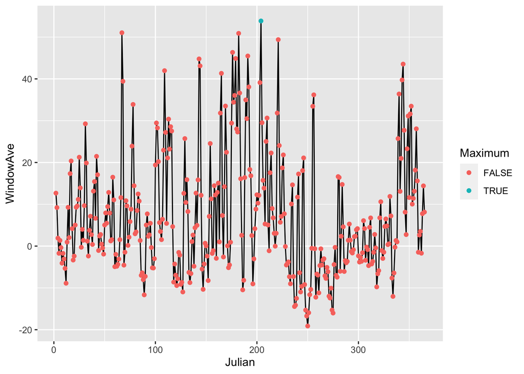

```r
flights %>%
  arrange( time_hour ) %>%
  mutate( Julian = yday(time_hour) ) %>%
  select( Julian, arr_delay ) %>%
  group_by( Julian ) %>%
  summarize( Delay = mean( arr_delay, na.rm=TRUE ) ) %>%
  mutate( WindowAve = data.table::frollmean( Delay, n=2 ) ) %>%
  mutate( Maximum = ifelse( WindowAve == max(WindowAve, na.rm=TRUE), TRUE, FALSE)) %>%
  filter( !is.na(Maximum) ) -> delays


most_delay <- month.day.year( delays$Julian[ delays$Maximum == TRUE],
                              origin = c(month=1,day=1,year=2013))


delays %>%
  ggplot( aes(Julian, WindowAve) ) +
  geom_line() + geom_point( aes(color=Maximum) )
```

The 48-hour period with the highest average delay was 7/24.

3. What are the five best and five worst airlines for keeping on schedule?

```r
flights %>%
  group_by( carrier ) %>%
  summarize( Delay = mean( arr_delay, na.rm=TRUE) ) %>%
  arrange( -Delay ) %>%
  left_join( airlines, by="carrier") %>%
  select( Carrier = name, Delay) %>%
  knitr::kable( digits=3, caption = "Average delay by carrier in 2013.") %>%
  kableExtra::kable_styling( full_width = FALSE )
```

Average delay by carrier in 2013.

| Carrier | Delay |
| --- | --- |
| Frontier Airlines Inc. | 21.921 |
| AirTran Airways Corporation | 20.116 |
| ExpressJet Airlines Inc. | 15.796 |
| Mesa Airlines Inc. | 15.557 |
| SkyWest Airlines Inc. | 11.931 |
| Envoy Air | 10.775 |
| Southwest Airlines Co. | 9.649 |
| JetBlue Airways | 9.458 |
| Endeavor Air Inc. | 7.380 |
| United Air Lines Inc. | 3.558 |
| US Airways Inc. | 2.130 |
| Virgin America | 1.764 |
| Delta Air Lines Inc. | 1.644 |
| American Airlines Inc. | 0.364 |
| Hawaiian Airlines Inc. | -6.915 |
| Alaska Airlines Inc. | -9.931 |

4. Independent of the length of the flight, are you more likely to be delayed by taking a large plane or a small plane?

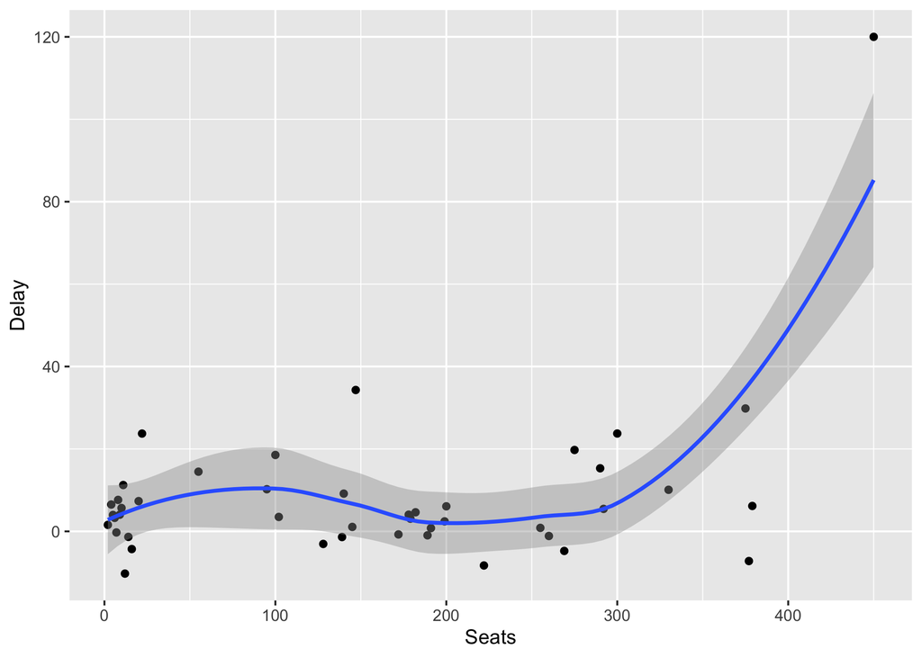

```r
flights %>%
  group_by( tailnum ) %>%
  summarize( AveDelay = mean( arr_delay, na.rm=TRUE) ) %>%
  left_join( planes, by="tailnum" ) %>%
  select( seats, AveDelay ) %>%
  group_by( seats ) %>%
  summarize( Delay = mean( AveDelay) ) %>%
  mutate( Seats = as.numeric( seats ) ) %>%
  ggplot( aes(Seats,Delay) ) +
  geom_point()  +
  stat_smooth()
```

5. Do all planes have tail numbers?

```r
flights %>%
  filter( is.na(tailnum)) %>%
  select( arr_time ) -> missing_tailnums

any(!is.na(missing_tailnums)  )
```

```
[1] FALSE
```

It looks like all flights with no `tailnum` are canceled flights

[^1]: If you get an error when attempting to load this library in, install it with `install.packages("nycflights13")` and then load it in again.